# Regression Modeling Using Python (A Test Case to Predict House Prices in King County, Seattle, U.S.A

## Aim of Project

How does one use regression modeling with Python to make predictions when given data with numerous possible predictor variables? This notebook aims to serve as a comprehensive guide on how to do this using data on houses in King County, Seattle, USA as a test case.

When I was learning regression modeling using Python, I wish I had a practical reference that synthesized all the concepts and skills under the topic so that learning would have been easier. I have applied all the concepts under regression modeling on a test case to show how Python can generate all types of regression models that can help other students and data science practitioners make meaningful predictions. In-sample model evaluation has been carried for demonstration purposes only to carry along anyone who might have difficulty understanding out-of-sample evaluation right of the bat. The sequencing, which is a key feature of this project, will be most beneficial to anyone who is struggling to synthesize and consolidate newly acquired skills and concepts in regression modeling.

### Motivation

To make it easier for other students and practitioners to learn and use regression modeling with Python.

### Source of Data

www.kaggle.com

#### Description of Data

This dataset contains house sale details for King County, which includes Seattle for the period May 2014 to May 2015.

**id** : A notation for a house; **date**: Date house was sold;**price**: Price is prediction target;**bedrooms**: Number of bedrooms;**bathrooms**: Number of bathrooms;**sqft_living**: Square footage of the home;**sqft_lot**: Square footage of the lot;**floors** :Total floors (levels) in house;**waterfront** :House which has a view to a waterfront;**view**: Has been viewed;**condition** :How good the condition is overall;**grade**: overall grade given to the housing unit, based on King County grading system;**sqft_above** : Square footage of house apart from basement;**sqft_basement**: Square footage of the basement;**yr_built** : Built Year;**yr_renovated** : Year when house was renovated;**zipcode**: Zip code;**lat**: Latitude coordinate;**long**: Longitude coordinate;**sqft_living15** : Living room area in 2015(implies-- some renovations) This might or might not have affected the lotsize area;**sqft_lot15** : LotSize area in 2015(implies-- some renovations)

### Project Details (The code for this project can be found in jupyter notebooks in my Gitbub and Kaggle Repositories)

Import python libraries need for data wrangling, visualization and regression modeling:

```python
import pandas as pd
import matplotlib.pyplot as plt
plt.style.use('ggplot')
import numpy as np
import seaborn as sns
from sklearn.pipeline import Pipeline
from sklearn.preprocessing import StandardScaler,PolynomialFeatures
from sklearn.linear_model import LinearRegression
%matplotlib inline
```

# 1.0 Importing and Understanding Data Sets

Load the csv:

```python
file_name='/Users/stoic/kc_house_data_NaN.csv'
df=pd.read_csv(file_name)
```

```python
df.head()
```

|  | Unnamed: 0 | id | date | price | bedrooms | bathrooms | sqft_living | sqft_lot | floors | waterfront | ... | grade | sqft_above | sqft_basement | yr_built | yr_renovated | zipcode | lat | long | sqft_living15 | sqft_lot15 |
| --- | --- | --- | --- | --- | --- | --- | --- | --- | --- | --- | --- | --- | --- | --- | --- | --- | --- | --- | --- | --- | --- |
| 0 | 0 | 7129300520 | 20141013T000000 | 221900.0 | 3.0 | 1.00 | 1180 | 5650 | 1.0 | 0 | ... | 7 | 1180 | 0 | 1955 | 0 | 98178 | 47.5112 | -122.257 | 1340 | 5650 |
| 1 | 1 | 6414100192 | 20141209T000000 | 538000.0 | 3.0 | 2.25 | 2570 | 7242 | 2.0 | 0 | ... | 7 | 2170 | 400 | 1951 | 1991 | 98125 | 47.7210 | -122.319 | 1690 | 7639 |
| 2 | 2 | 5631500400 | 20150225T000000 | 180000.0 | 2.0 | 1.00 | 770 | 10000 | 1.0 | 0 | ... | 6 | 770 | 0 | 1933 | 0 | 98028 | 47.7379 | -122.233 | 2720 | 8062 |
| 3 | 3 | 2487200875 | 20141209T000000 | 604000.0 | 4.0 | 3.00 | 1960 | 5000 | 1.0 | 0 | ... | 7 | 1050 | 910 | 1965 | 0 | 98136 | 47.5208 | -122.393 | 1360 | 5000 |
| 4 | 4 | 1954400510 | 20150218T000000 | 510000.0 | 3.0 | 2.00 | 1680 | 8080 | 1.0 | 0 | ... | 8 | 1680 | 0 | 1987 | 0 | 98074 | 47.6168 | -122.045 | 1800 | 7503 |

5 rows × 22 columns

Display the data types of each column using the attribute df.dtypes to check if type of data in columns match the column labels. Any issue of wrong data type in column can be identified and rectified after this code is run.

```python
df.dtypes
```

```
Unnamed: 0         int64
id                 int64
date              object
price            float64
bedrooms         float64
bathrooms        float64
sqft_living        int64
sqft_lot           int64
floors           float64
waterfront         int64
view               int64
condition          int64
grade              int64
sqft_above         int64
sqft_basement      int64
yr_built           int64
yr_renovated       int64
zipcode            int64
lat              float64
long             float64
sqft_living15      int64
sqft_lot15         int64
dtype: object
```

Take a cursory glance statistical summary of the dataframe

```python
df.describe()
```

|  | Unnamed: 0 | id | price | bedrooms | bathrooms | sqft_living | sqft_lot | floors | waterfront | view | ... | grade | sqft_above | sqft_basement | yr_built | yr_renovated | zipcode | lat | long | sqft_living15 | sqft_lot15 |
| --- | --- | --- | --- | --- | --- | --- | --- | --- | --- | --- | --- | --- | --- | --- | --- | --- | --- | --- | --- | --- | --- |
| count | 21613.00000 | 2.161300e+04 | 2.161300e+04 | 21600.000000 | 21603.000000 | 21613.000000 | 2.161300e+04 | 21613.000000 | 21613.000000 | 21613.000000 | ... | 21613.000000 | 21613.000000 | 21613.000000 | 21613.000000 | 21613.000000 | 21613.000000 | 21613.000000 | 21613.000000 | 21613.000000 | 21613.000000 |
| mean | 10806.00000 | 4.580302e+09 | 5.400881e+05 | 3.372870 | 2.115736 | 2079.899736 | 1.510697e+04 | 1.494309 | 0.007542 | 0.234303 | ... | 7.656873 | 1788.390691 | 291.509045 | 1971.005136 | 84.402258 | 98077.939805 | 47.560053 | -122.213896 | 1986.552492 | 12768.455652 |
| std | 6239.28002 | 2.876566e+09 | 3.671272e+05 | 0.926657 | 0.768996 | 918.440897 | 4.142051e+04 | 0.539989 | 0.086517 | 0.766318 | ... | 1.175459 | 828.090978 | 442.575043 | 29.373411 | 401.679240 | 53.505026 | 0.138564 | 0.140828 | 685.391304 | 27304.179631 |
| min | 0.00000 | 1.000102e+06 | 7.500000e+04 | 1.000000 | 0.500000 | 290.000000 | 5.200000e+02 | 1.000000 | 0.000000 | 0.000000 | ... | 1.000000 | 290.000000 | 0.000000 | 1900.000000 | 0.000000 | 98001.000000 | 47.155900 | -122.519000 | 399.000000 | 651.000000 |
| 25% | 5403.00000 | 2.123049e+09 | 3.219500e+05 | 3.000000 | 1.750000 | 1427.000000 | 5.040000e+03 | 1.000000 | 0.000000 | 0.000000 | ... | 7.000000 | 1190.000000 | 0.000000 | 1951.000000 | 0.000000 | 98033.000000 | 47.471000 | -122.328000 | 1490.000000 | 5100.000000 |
| 50% | 10806.00000 | 3.904930e+09 | 4.500000e+05 | 3.000000 | 2.250000 | 1910.000000 | 7.618000e+03 | 1.500000 | 0.000000 | 0.000000 | ... | 7.000000 | 1560.000000 | 0.000000 | 1975.000000 | 0.000000 | 98065.000000 | 47.571800 | -122.230000 | 1840.000000 | 7620.000000 |
| 75% | 16209.00000 | 7.308900e+09 | 6.450000e+05 | 4.000000 | 2.500000 | 2550.000000 | 1.068800e+04 | 2.000000 | 0.000000 | 0.000000 | ... | 8.000000 | 2210.000000 | 560.000000 | 1997.000000 | 0.000000 | 98118.000000 | 47.678000 | -122.125000 | 2360.000000 | 10083.000000 |
| max | 21612.00000 | 9.900000e+09 | 7.700000e+06 | 33.000000 | 8.000000 | 13540.000000 | 1.651359e+06 | 3.500000 | 1.000000 | 4.000000 | ... | 13.000000 | 9410.000000 | 4820.000000 | 2015.000000 | 2015.000000 | 98199.000000 | 47.777600 | -121.315000 | 6210.000000 | 871200.000000 |

8 rows × 21 columns

The data has 21,613 row entries. We can also tell from the statistal summary that 'Unamed:0' and 'id' columns will not be useful for prediction modeling of house prices.

# 2.0 Data Wrangling

Drop columns that will not be needed.

```python
df.drop(["id","Unnamed: 0"],axis=1, inplace=True)
df.describe()
```

|  | price | bedrooms | bathrooms | sqft_living | sqft_lot | floors | waterfront | view | condition | grade | sqft_above | sqft_basement | yr_built | yr_renovated | zipcode | lat | long | sqft_living15 | sqft_lot15 |
| --- | --- | --- | --- | --- | --- | --- | --- | --- | --- | --- | --- | --- | --- | --- | --- | --- | --- | --- | --- |
| count | 2.161300e+04 | 21600.000000 | 21603.000000 | 21613.000000 | 2.161300e+04 | 21613.000000 | 21613.000000 | 21613.000000 | 21613.000000 | 21613.000000 | 21613.000000 | 21613.000000 | 21613.000000 | 21613.000000 | 21613.000000 | 21613.000000 | 21613.000000 | 21613.000000 | 21613.000000 |
| mean | 5.400881e+05 | 3.372870 | 2.115736 | 2079.899736 | 1.510697e+04 | 1.494309 | 0.007542 | 0.234303 | 3.409430 | 7.656873 | 1788.390691 | 291.509045 | 1971.005136 | 84.402258 | 98077.939805 | 47.560053 | -122.213896 | 1986.552492 | 12768.455652 |
| std | 3.671272e+05 | 0.926657 | 0.768996 | 918.440897 | 4.142051e+04 | 0.539989 | 0.086517 | 0.766318 | 0.650743 | 1.175459 | 828.090978 | 442.575043 | 29.373411 | 401.679240 | 53.505026 | 0.138564 | 0.140828 | 685.391304 | 27304.179631 |
| min | 7.500000e+04 | 1.000000 | 0.500000 | 290.000000 | 5.200000e+02 | 1.000000 | 0.000000 | 0.000000 | 1.000000 | 1.000000 | 290.000000 | 0.000000 | 1900.000000 | 0.000000 | 98001.000000 | 47.155900 | -122.519000 | 399.000000 | 651.000000 |
| 25% | 3.219500e+05 | 3.000000 | 1.750000 | 1427.000000 | 5.040000e+03 | 1.000000 | 0.000000 | 0.000000 | 3.000000 | 7.000000 | 1190.000000 | 0.000000 | 1951.000000 | 0.000000 | 98033.000000 | 47.471000 | -122.328000 | 1490.000000 | 5100.000000 |
| 50% | 4.500000e+05 | 3.000000 | 2.250000 | 1910.000000 | 7.618000e+03 | 1.500000 | 0.000000 | 0.000000 | 3.000000 | 7.000000 | 1560.000000 | 0.000000 | 1975.000000 | 0.000000 | 98065.000000 | 47.571800 | -122.230000 | 1840.000000 | 7620.000000 |
| 75% | 6.450000e+05 | 4.000000 | 2.500000 | 2550.000000 | 1.068800e+04 | 2.000000 | 0.000000 | 0.000000 | 4.000000 | 8.000000 | 2210.000000 | 560.000000 | 1997.000000 | 0.000000 | 98118.000000 | 47.678000 | -122.125000 | 2360.000000 | 10083.000000 |
| max | 7.700000e+06 | 33.000000 | 8.000000 | 13540.000000 | 1.651359e+06 | 3.500000 | 1.000000 | 4.000000 | 5.000000 | 13.000000 | 9410.000000 | 4820.000000 | 2015.000000 | 2015.000000 | 98199.000000 | 47.777600 | -121.315000 | 6210.000000 | 871200.000000 |

Check for empty entries.

```python
pd.isnull(df).sum()
```

```
date              0
price             0
bedrooms         13
bathrooms        10
sqft_living       0
sqft_lot          0
floors            0
waterfront        0
view              0
condition         0
grade             0
sqft_above        0
sqft_basement     0
yr_built          0
yr_renovated      0
zipcode           0
lat               0
long              0
sqft_living15     0
sqft_lot15        0
dtype: int64
```

In this case, I am dealing with the number of bedrooms and bathrooms, hence replacing the entries with mean values of the entire column would be more beneficial than deleting rows with empty entries in the 'bedrooms' and 'bathroom' columns.

Furthermore, the larger our dataset is, the more accurate our prediction model is going to be. It would be unwise to delete entire rows just because of empty entries in two columns.

```python
mean=df['bedrooms'].mean()
df['bedrooms'].replace(np.nan,mean, inplace=True)
mean=df['bathrooms'].mean()
df['bathrooms'].replace(np.nan,mean, inplace=True)
```

Check to confirm if all the empty entries have been dealt with.

```python
pd.isnull(df).sum()
```

```
date             0
price            0
bedrooms         0
bathrooms        0
sqft_living      0
sqft_lot         0
floors           0
waterfront       0
view             0
condition        0
grade            0
sqft_above       0
sqft_basement    0
yr_built         0
yr_renovated     0
zipcode          0
lat              0
long             0
sqft_living15    0
sqft_lot15       0
dtype: int64
```

# 3: Exploratory Data Analysis

Exploratory data analysis is carried out to acquire an intuitive understanding of our data, especially the correlation between the dependent(target) variable, which is house prices in this project, and independent(feature or predictor) variables.

How many unique floor numbers does our dataset have and what are their numbers?

```python
df_floors = df['floors'].value_counts().to_frame()
df_floors
```

|  | floors |
| --- | --- |
| 1.0 | 10680 |
| 2.0 | 8241 |
| 1.5 | 1910 |
| 3.0 | 613 |
| 2.5 | 161 |
| 3.5 | 8 |

We can use the function `regplot` in the seaborn library to determine if the feature `sqft_above` is negatively or positively correlated with price.

```
(0, 8085730.054150553)
```

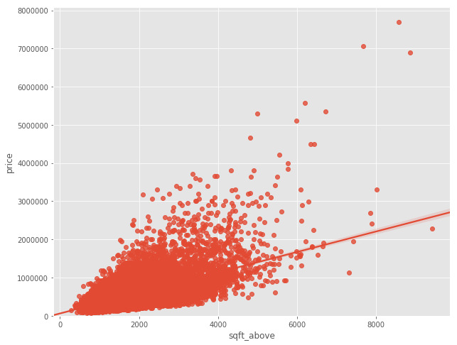

```python
plt.figure(figsize=(10, 8))
sns.regplot(x="sqft_above", y="price", data=df)
plt.ylim(0,)
```

Seaborn regression plot shows that there is positive correlation between 'sqft_bove' and the 'price'.

#### Most importantly, when carrying out exploratory data analyis, it is vital that the correlation between all the independent variables (features) and the dependent variable (target) is examined.

```python
corr_df = df.corr()['price'].sort_values(ascending=False).to_frame()
corr_df.index.name = 'feature'
corr_df
```

| feature | price |
| --- | --- |
| price | 1.000000 |
| sqft_living | 0.702035 |
| grade | 0.667434 |
| sqft_above | 0.605567 |
| sqft_living15 | 0.585379 |
| bathrooms | 0.525738 |
| view | 0.397293 |
| sqft_basement | 0.323816 |
| bedrooms | 0.308797 |
| lat | 0.307003 |
| waterfront | 0.266369 |
| floors | 0.256794 |
| yr_renovated | 0.126434 |
| sqft_lot | 0.089661 |
| sqft_lot15 | 0.082447 |
| yr_built | 0.054012 |
| condition | 0.036362 |
| long | 0.021626 |
| zipcode | -0.053203 |

This helps determine which independent variables to consider for model development. The higher the correlation is between an independent variable and the target variable, the higher the odds of generating an accurate model.

# 4: Model Development and Evaluation - In-sample Evaluation

### In this section, 100% of the data will be used as training data in this section (in-sample evaluation). In practice, this is not done because no data would be left with which I can evaluate our model. Also, reusing the same data for training and testing is a bad idea because I need to know how the method will work on data it was not trained on. However, in section 5 below, I will split our data for training and testing, in keeping with standard practice. Before we run simple and multiple linear regression analysis, we shoud determine if the relationship between the topmost correlated independent variables and the target variable is linear

I will use residual plots to do this.

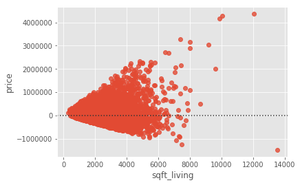

```python
sns.residplot(x=df['sqft_living'], y=df['price'])
```

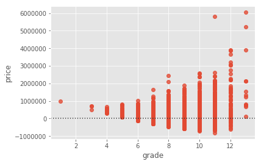

```python
sns.residplot(x=df['grade'], y=df['price'])
```

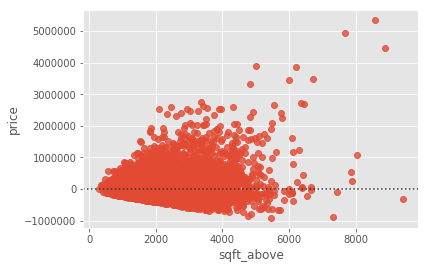

```python
sns.residplot(x=df['sqft_above'], y=df['price'])
```

It can be seen that the data points are not distributed evenly around the x-axis with similar variance in all the residual plots. This suggests that the linear assumption is not correct. A polynomial assumption will be tested.

### Although it has been proven that the relationship between the independent variables and the target variable is not linear, I will go ahead and determine the coefficient of determination (R^2) for different variables for demonstration purposes, only.

### Linear Regression with single independent variable

Test Simple Linear Regression with each possible independent variable and caculate the respective Coefficient of determination (R^2).

```python
R_square = []
indep_var_label = ['sqft_living', 'grade', 'sqft_above', 'sqft_living15','bathrooms', 'view', 'sqft_basement',
                 'bedrooms', 'lat', 'waterfront', 'floors', 'yr_renovated', 'sqft_lot', 'sqft_lot15','yr_built',
                 'condition', 'long', 'zipcode']

for label in indep_var_label:
    X = df[[label]]
    Y = df['price']
    lm = LinearRegression()
    lm.fit(X,Y)
    R_square.append(lm.score(X, Y))
```

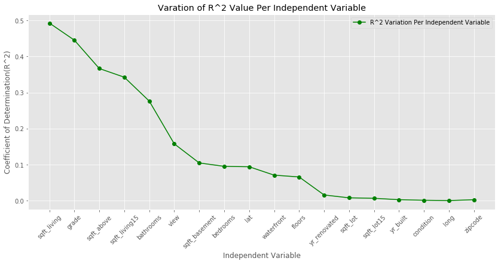

```python
plt.figure(figsize=(14, 6))

ax = plt.subplot()
plt.plot(indep_var_label, R_square, color='g', marker='o', label='R^2 Variation Per Independent Variable')
ax.set_xticks(indep_var_label)
ax.set_xticklabels(indep_var_label, rotation=45)
plt.title('Varation of R^2 Value Per Independent Variable')
plt.xlabel('Independent Variable')
plt.ylabel('Coefficient of Determination(R^2)')
plt.legend()
```

The chart shows that the maximum coefficient of determination (R^2) using univariate linear regression to determine the target price is approximately 0.5. In other words, at best, 50% of the variability observed in the prices is accounted for by a single feature under a linear regression.

### Linear Regression with multiple independent variables

Select the top 5 independent variables that closely correlate with our target variable of price. Then we select determine the (R^2) value.

```python
feat_top5 = ['sqft_living', 'grade', 'sqft_above', 'sqft_living15','bathrooms']
X1 = df[feat_top5]
Y = df['price']
lm1 = LinearRegression()
lm1.fit(X1,Y)
R_mr1 = lm1.score(X1,Y)
f"The coefficient of determination (R^2) is", {R_mr1}
```

```
('The coefficient of determination (R^2) is', {0.5441584243667872})
```

Run a linear regression model with all the independent variables to check if we will get a higher R^2 score.

```python
feat_all = ['sqft_living', 'grade', 'sqft_above', 'sqft_living15','bathrooms', 'view', 'sqft_basement', 'bedrooms', 'lat', 'waterfront', 'floors', 'yr_renovated', 'sqft_lot', 'sqft_lot15','yr_built', 'condition', 'long', 'zipcode']
X2 = df[feat_all]
Y = df['price']
lm2 = LinearRegression()
lm2.fit(X2,Y)
R_mr2 = lm2.score(X2,Y)
f"The coefficient of determination (R^2) is", {R_mr2}
```

```
('The coefficient of determination (R^2) is', {0.6997513873758985})
```

It can be seen that the coefficient of determination rises by 28.6% to 0.699 when I run linear regression with all the independent variables.

Although this is a marked improvement, we should remember that the residual plots proved that the relationship between the independent variables and target variable is not linear.

Distribution plots are very useful in determining how accurately our model predicts the target variables with multiple linear regressions when dealing with continuous data. I will plot a distribution plot to visualize the difference between the frequency of occurrence of the actual target variables and the predicted values from the model using all predictor variables

```
[(0, 4000000)]
```

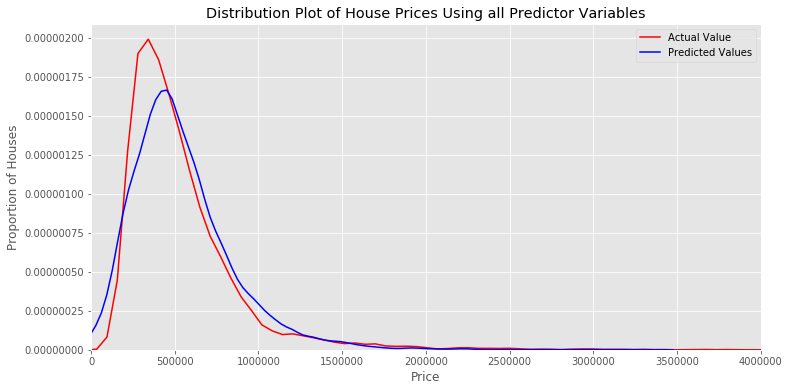

```python
# Predict the Target Variables for Each Row of Independent Variables Using the Model That Has Just Been Generated
Y_predict2 = lm2.predict(X2)

# Plot Distribution Plot for Multiple Linear Regression
plt.figure(figsize=(12,6))
ax1 = sns.distplot(df['price'], hist=False, color='r', label='Actual Value')
sns.distplot(Y_predict2, hist=False, color='b', label='Predicted Values', ax=ax1)
plt.title('Distribution Plot of House Prices Using all Predictor Variables')
plt.ylabel('Proportion of Houses')
plt.xlabel('Price')
ax1.set(xlim=(0, 4000000))
```

The distribution plot reveals that the multiple linear regression model does not perform well for price ranges less than $500,000.00

## Polynomial Regression with Single Independent Variable

Select the square footage of the home as our single independent variable because of its high correlation with house prices. I will define a function to plot our data and model.

```python
def single_var_polyplot(model, indepen_var, depen_var, name):
    x_new = np.linspace(290, 13540, 100)
    y_new = model(x_new)

    plt.figure(figsize=(12,6))
    plt.plot(indepen_var, depen_var, '.', x_new, y_new, '-')
    plt.title('Polynomial Model with Single Predictor Variable')
    ax = plt.gca()
    fig = plt.gcf()
    plt.xlabel(name)
    plt.ylabel('House Prices')
    plt.show()
    plt.close()
```

Select our predictor and target variables and select a seventh order polynomial model to fit to our data.

```python
x = df['sqft_living']
y = df['price']

# We will consider a 7th order polynomial (cubic) model. We shall fit the polynomial to our data using
# *polyfit* function and then use the *poly1d* function to display it.
seventh_order_func = np.polyfit(x, y, 7)
seventh_order_model = np.poly1d(seventh_order_func)
print(seventh_order_model)
```

```
           7             6             5            4            3
5.517e-21 x - 3.389e-16 x + 7.233e-12 x - 7.15e-08 x + 0.000355 x
           2
 - 0.8343 x + 1032 x - 1.617e+05
```

Plot the model using the single_var_polyplot function defined above.

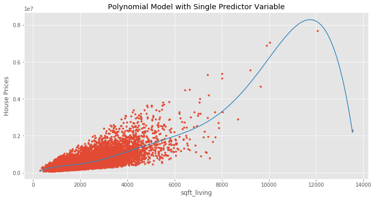

```python
single_var_polyplot(seventh_order_model, x, y, 'sqft_living')
```

From the visualization, I notice that our data is skewed when we consider only the predictor value of square footage of the house, even though the seventh order fits even outliers of the data. This may suggest that the single predictor variable of square footage of the house does not generate an accurate model.

I tried another predictor variable. This time, the overall grade given to the housing unit, based on King County grading system.

```python
x1 = df['grade']
y1 = df['price']

# I consider a 7th order polynomial (cubic) model. We shall fit the polynomial to our data using
# *polyfit* function and then use the *poly1d* function to display it.
seventh_order1_func = np.polyfit(x1, y1, 7)
seventh_order1_model = np.poly1d(seventh_order1_func)
print(seventh_order1_model)
```

```
       7         6        5             4             3             2
8.391 x - 400.2 x + 7864 x - 8.175e+04 x + 4.813e+05 x - 1.569e+06 x + 2.528e+06 x - 1.229e+06
```

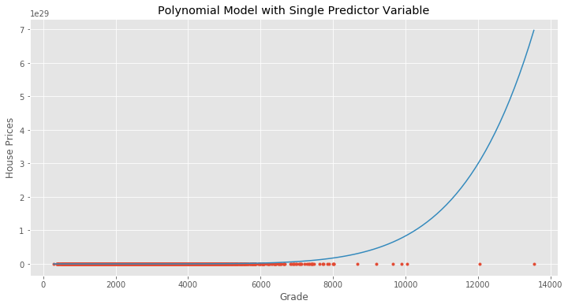

```python
single_var_polyplot(seventh_order1_model, x, y, 'Grade')
```

I proceed and investigate whether polynomial regressions with multiple independent variable will yield more accurate prediction models.

## Polynomial Regression with Multiple Independent Variables

### Pipelines

What do we do when a linear model and a univariate polynomial model is not the best fit for our data? We evaluate our data using multivariate polynomial regression. This involves transforming our data into a polynomial and using linear regression to fit the data. However, this is convulated process for more than one independent variable hence, pipelines are employed to simplify our code and make it efficient.

Pipelines are employed to simplify long-winded code involving normalization, transforming and model generation using linear regression.

Structurally, pipelines consist of a list of tuples. The first element in the tuple contains the name of the estimator and the second element contains the the model constructor:

Estimator:

`'scale'`

`'polynomial'`

`'model'`

Model Constructor:

`StandardScaler()`

`PolynomialFeatures(include_bias=False)`

`LinearRegression()`

The default degree parameter of `PolynomialFeatures` is 2 so it is not necessary to include it but it has been included for demonstration purposes only.

```python
Pipeline_Input=[('scale',StandardScaler()),('polynomial', PolynomialFeatures(degree=2)),('model',LinearRegression())]
```

I use the list - 'Input' to create a pipeline object to predict house prices, fit the object using the top five correlated variables (see `feat_top5()` above). We iterate through different orders of the polynomial function to determine which order will yield the highest coefficient of determination (R^2).

```python
R_square_pipe = []
feat_top5 = ['sqft_living', 'grade', 'sqft_above', 'sqft_living15','bathrooms']
poly_order = range(2,11)

for n in poly_order:
    Input=[('scale',StandardScaler()),('polynomial', PolynomialFeatures(degree=n)),('model',LinearRegression())]
    pipe = Pipeline(Input)
    pipe.fit(df[feat_top5], df['price'])
    R_pipe = pipe.score(df[feat_top5], df['price'])
    R_square_pipe.append(R_pipe)
```

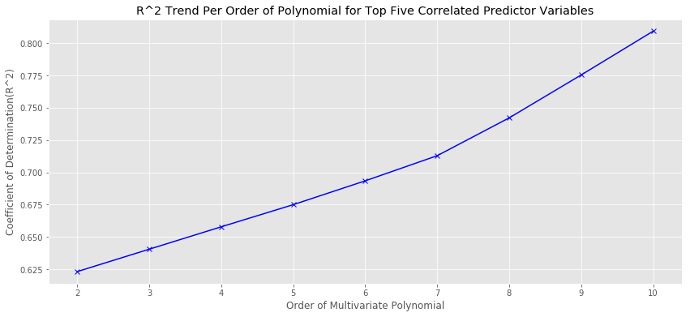

```python
plt.figure(figsize=(14, 6))

ax = plt.subplot()
plt.plot(poly_order, R_square_pipe, color='blue', marker='x', label='Coefficient of Determination (R^2)')
plt.title('R^2 Trend Per Order of Polynomial for Top Five Correlated Predictor Variables')
plt.xlabel('Order of Multivariate Polynomial')
plt.ylabel('Coefficient of Determination(R^2)')
plt.show()
```

NB: I had the capacity to only evaluate up to a tenth (10th) order multivariate using a laptop in Ghana. Orders higher than ten resulted in long processing times.

Nevertheless, the visualization from the multivariate polynomial shows that the higher the order of polyninomial, the better our model performs. As a result a tenth (10th) order multivariate regression using the top five correlated independent variables yields a coefficient of determination of approximately 0.81.

This means that with a 10th order polynomial regression, 81% of the variation in house prices can be explained by top five(5) correlated predictor variables.

#### Learning: The more variables you choose to train a polynomial regression model, the more computing power you need.

# 5: Model Development and Evaluation - Out-of-sample Evaluation

The problem with in-sample evaluation is that it does not give us an estimate of how well the trained model performs in the real world with new data. To avoid this problem, it is vital to split our data up into training data and testing data. We import the train_test module to split our data into train and test data randomly.

```python
from sklearn.model_selection import train_test_split
```